# Html_Tiktok_ContentPlatform

## Load data

```python
# Load the dataframes from csv files
import pandas as pd

User_Actions = pd.read_csv("https://storage.googleapis.com/datalynn-datasets/interview-challenge/technology/Tiktok_ContentPlatform/User_Actions.csv")
Video_Details = pd.read_csv("https://storage.googleapis.com/datalynn-datasets/interview-challenge/technology/Tiktok_ContentPlatform/Video_Details.csv")
```

## Q1

**Original Question**:

**Scenario:** As a part of content moderation, it is important to identify potential patterns of inappropriate content. You are tasked with identifying trends in flagged content over time.

- Using Table 1, write an SQL command to find the number of flagged videos by content_type per month. Can you identify any seasonal trends or patterns that might suggest automated uploads of inappropriate content?

### Solution

The problem at hand requires identifying the trends in flagged content over time, and specifically categorizing them by content type and aggregating them monthly. This could help in identifying any seasonal patterns or unusual spikes in flagged content that might suggest automated uploads of inappropriate content.

**Problem-solving Ideas and Tips:**

1. **Filter by Flag Status**: First, we need to filter the records where the `flag_status` is flagged (or the appropriate value denoting flagged content).
2. **Extract the Month**: We'll need to extract the month from the `upload_date` field.
3. **Group by Content Type and Month**: We'll group the results by `content_type` and the extracted month, then count the number of flagged videos for each grouping.
4. **Analyze the Trends**: The result will allow us to see how the number of flagged videos varies by content type and month. From this, we can identify any patterns, such as regular spikes in flagged content, that might suggest automated or seasonal activity.

Here's the SQL command that will achieve this in SQLite:

```python
import sqlite3

# Connect to SQLite database
conn = sqlite3.connect('tiktok_data.db')

# Convert pandas dataframes to SQL tables
Video_Details.to_sql('Video_Details', conn, if_exists='replace', index=False)
User_Actions.to_sql('User_Actions', conn, if_exists='replace', index=False)

# SQL query to find the number of flagged videos by content_type per month
query = """
SELECT content_type,
       strftime('%Y-%m', upload_date) as month,
       COUNT(video_id) as flagged_count
FROM Video_Details
WHERE flag_status = 'flagged'
GROUP BY content_type, month
ORDER BY month ASC, flagged_count DESC;
"""

# Execute the query
cursor = conn.execute(query)
results = cursor.fetchall()
```

Then we could further analyze the results to identify patterns or trends. Visualizing the data with a time series plot could also be beneficial to identify seasonal trends or other patterns that might indicate automated uploads.

Here's how to analyze and visualize the results:

1. **Convert Results to DataFrame**: We'll convert the SQL query results into a pandas DataFrame for easy manipulation and plotting.
2. **Pivot the Data**: We'll pivot the DataFrame so that each content type has its own column. This allows us to plot each content type's trend on the same graph.
3. **Visualize Using Time Series Plot**: We'll use a line plot to visualize the time series data, which allows us to easily identify any trends or patterns.

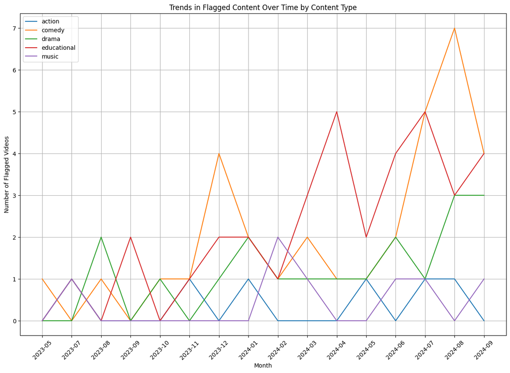

```python
import matplotlib.pyplot as plt

# Convert the results to a pandas DataFrame
flagged_df = pd.DataFrame(results, columns=['content_type', 'month', 'flagged_count'])

# Pivot the data to have content_type as columns
pivot_df = flagged_df.pivot(index='month', columns='content_type', values='flagged_count')
pivot_df.fillna(0, inplace=True) # Replace NaN values with 0

# Plot the time series for each content_type
plt.figure(figsize=[15, 10])
for content_type in pivot_df.columns:
    plt.plot(pivot_df.index, pivot_df[content_type], label=content_type)

plt.xlabel('Month')
plt.ylabel('Number of Flagged Videos')
plt.title('Trends in Flagged Content Over Time by Content Type')
plt.legend()
plt.xticks(rotation=45)
plt.grid(True)
plt.show()
```

### Analysis

- **Seasonal Patterns**: Look for repeating patterns at specific times of the year. This might indicate a seasonal trend.
- **Sudden Spikes**: If there are sudden spikes in flagged content for specific content types, this might suggest automated uploads of inappropriate content.
- **Content Type Specific Trends**: Analyzing the trends by content type helps in understanding if particular content types are more prone to violations.

## Q2

**Original Question**:

**Scenario:** TikTok wants to optimize its 'For You' feed to better understand how users engage with different types of content.

- Using Tables 1 and 2, how would you design an experiment to understand the correlation between content_type and user engagement (e.g., views, likes)? What challenges might arise due to high correlation between different types of engagement?

### Solution

To understand the correlation between content_type and user engagement (e.g., views, likes) using Tables 1 and 2, we can design an experiment as follows:

**1. Define the Metrics of Engagement:**

- **Views**: The number of times a video has been watched.
- **Likes**: The number of likes a video has received.

(Other metrics such as comments, shares, and reports can also be included.)

**2. Segment by Content Type:**

- Divide the data by different content types such as comedy, educational, music, sports, etc.

**3. Aggregate the Engagement Metrics:**

- For each content type, calculate the sum of views, likes, etc.
- Calculate ratios like the number of likes per view for more nuanced insights.

**4. Statistical Analysis:**

- Perform correlation analysis to understand the relationships between different content types and engagement metrics.
- If required, conduct hypothesis testing to determine if observed correlations are statistically significant.

**5. Visualization:**

- Plot the data to visualize trends and patterns across different content types.

**Challenges and Considerations:**

- **High Correlation Between Different Types of Engagement**: A high correlation between views and likes, for example, might make it difficult to disentangle what specifically drives engagement.
- **Content Quality Variation**: Different content types may have varying quality, which can influence engagement.
- **Bias in Content Exposure**: Algorithmic biases or user preferences can affect which content types are more frequently exposed, thus skewing results.
- **Temporal Effects**: Seasonal trends or time-based events can influence engagement and should be controlled for.
- **Spurious Correlations**: Correlation does not imply causation, and external factors might cause spurious correlations.

**Potential Implementation (in Python):**

```python
import pandas as pd
import numpy as np
import scipy.stats as stats

views = User_Actions[User_Actions['action_type'] == 'view']
likes = User_Actions[User_Actions['action_type'] == 'like']

# Merging with Video_Details to get content type
views_with_type = views.merge(Video_Details[['video_id', 'content_type']], on='video_id')
likes_with_type = likes.merge(Video_Details[['video_id', 'content_type']], on='video_id')

# Counting views and likes per content type
views_count = views_with_type['content_type'].value_counts().reset_index().rename(columns={'index': 'content_type', 'content_type': 'views'})
likes_count = likes_with_type['content_type'].value_counts().reset_index().rename(columns={'index': 'content_type', 'content_type': 'likes'})

# Merging the counts
engagement_metrics = pd.merge(views_count, likes_count, on='content_type', how='outer').fillna(0)

# Calculating the likes per view ratio
engagement_metrics['likes_per_view'] = engagement_metrics['likes'] / engagement_metrics['views']

# Calculating correlation matrix
correlation_matrix = engagement_metrics.corr(numeric_only=True)
print(correlation_matrix)

# Forming the Contingency Table
contingency_table = engagement_metrics.pivot_table(index='content_type', values=['views', 'likes'], aggfunc=np.sum)
print("\nContingency Table:\n", contingency_table)

# Performing the Chi-Squared test
chi2_statistic, p_value, _, _ = stats.chi2_contingency(contingency_table)

print('\nChi-squared statistic:', chi2_statistic)
print('P-value:', p_value)

# Interpret the result
if p_value < 0.05:
    print('There is a statistically significant difference between views and likes across content types.')
else:
    print('There is no statistically significant difference between views and likes across content types.')
```

```
                   views     likes  likes_per_view
views           1.000000  0.905325       -0.530615
likes           0.905325  1.000000       -0.210671
likes_per_view -0.530615 -0.210671        1.000000

Contingency Table:
               likes  views
content_type
action           33    171
comedy          312   1381
drama           121    790
educational     205   1542
music            53    183

Chi-squared statistic: 42.540472896067705
P-value: 1.2887791752030654e-08
There is a statistically significant difference between views and likes across content types.
```

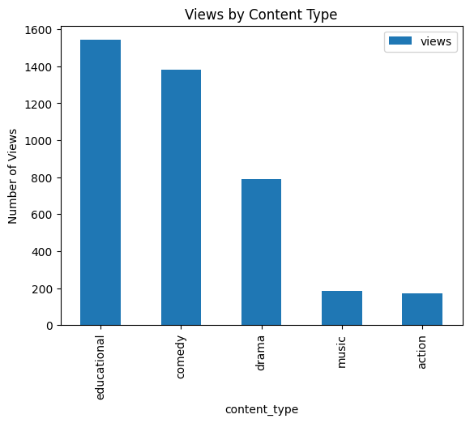

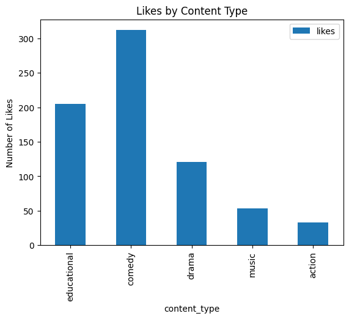

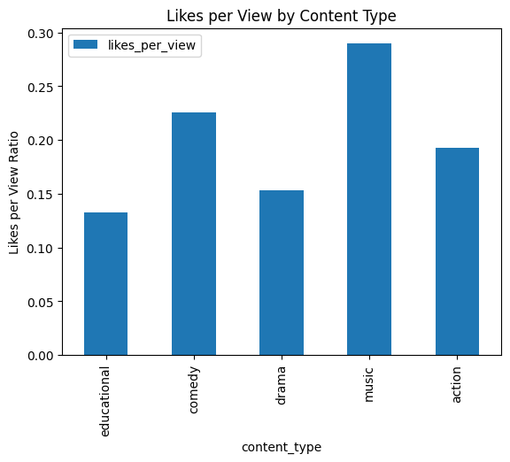

```python
import matplotlib.pyplot as plt

# Plotting views by content type
engagement_metrics.plot(x='content_type', y='views', kind='bar')
plt.title('Views by Content Type')
plt.ylabel('Number of Views')
plt.show()

# Plotting likes by content type
engagement_metrics.plot(x='content_type', y='likes', kind='bar')
plt.title('Likes by Content Type')
plt.ylabel('Number of Likes')
plt.show()

# Plotting likes per view ratio by content type
engagement_metrics.plot(x='content_type', y='likes_per_view', kind='bar')
plt.title('Likes per View by Content Type')
plt.ylabel('Likes per View Ratio')
plt.show()
```

This code snippet demonstrates how to merge the two tables and group the data by content type, then aggregate the metrics for views and likes. The correlation matrix provides insights into the relationships between these different metrics across content types.

In conclusion, careful consideration of these aspects, along with robust statistical analysis and clear visualization, would provide insights into the correlation between content type and user engagement on TikTok.

## Q3

**Original Question**:

**Scenario:** Based on the insights from Question 1, your next task is to create a machine learning model to detect suspicious patterns that may indicate automated uploads of inappropriate content.

- Describe a machine learning model to detect this specific behavior. What features would you consider, and what evaluation metric (such as Recall) would be most appropriate here? How might the insights from Question 1 inform your feature engineering?

### Solution

Creating a machine learning model to detect suspicious patterns indicative of automated uploads of inappropriate content involves careful selection of features and the appropriate model, as well as considering evaluation metrics that align with the business problem.

**1. Feature Selection:**

- **Content Type**: From the insights of Question 1, if there are certain content types more prone to being flagged, this information can be crucial.
- **Upload Frequency**: The frequency of uploads by the same uploader in a short time span may indicate automated behavior.
- **Uploader History**: The previous flagging history of the uploader could be indicative.
- **Temporal Patterns**: Time-related features like the day of the week, hour of the day, or any specific pattern found in flagged content (e.g., seasonal trends) can be important.
- **User Engagement**: If automated, such videos may have different patterns of user engagement (likes, views, etc.).
- **Text or Metadata Analysis**: If available, analyzing the titles, tags, or descriptions using NLP techniques could provide insights into the content.

**2. Model Selection:** An ensemble model like Random Forest or Gradient Boosting may be effective here, given the potential complexity of patterns. These models can capture non-linear relationships and handle various data types.

**3. Evaluation Metrics:**

- **Recall**: Since it's crucial to detect as many inappropriate contents as possible, maximizing recall may be a priority. A high recall ensures that most of the inappropriate contents are detected, even if some appropriate contents are mistakenly flagged.
- **Precision-Recall Curve**: Analyzing both precision and recall to find the optimal balance may be important, as focusing solely on recall might increase false positives.
- **F1 Score**: Harmonic mean of precision and recall can also be used to balance both.

**4. How Insights from Question 1 Inform Feature Engineering:**

- **Seasonal Patterns**: If there are clear seasonal trends in flagged content, features capturing these patterns can be engineered.
- **Content-Type Sensitivity**: If certain content types are more frequently flagged, this can be a crucial feature.
- **Anomaly Detection**: If certain patterns of bulk uploads are detected, features capturing these anomalies can be created.

**5. Preprocessing & Training:**

- **Handle Imbalanced Data**: If flagged content is rare, techniques such as resampling or using weighted loss functions may be needed.
- **Temporal Splits**: If temporal trends are significant, time-based validation splits must be considered to avoid leakage.

The model's success would largely depend on quality feature engineering, aligned with insights from the exploratory analysis (Question 1), and the careful tuning of model hyperparameters. Monitoring the model's performance on new data and iterative refinement with feedback from the moderation team would be key to maintaining its effectiveness.

```python
from sklearn.model_selection import train_test_split
from sklearn.ensemble import RandomForestClassifier
from sklearn.metrics import recall_score, f1_score, precision_score
from imblearn.over_sampling import SMOTE

# Define additional features based on insights
Video_Details['upload_frequency'] = Video_Details.groupby('uploader_id')['upload_date'].transform('count')
Video_Details['uploader_history'] = Video_Details.groupby('uploader_id').cumcount()

Video_Details['upload_date'] = pd.to_datetime(Video_Details['upload_date'])
Video_Details['day_of_week'] = Video_Details['upload_date'].dt.dayofweek
Video_Details['hour_of_day'] = Video_Details['upload_date'].dt.hour

# Define the target variable
Video_Details['target'] = (Video_Details['flag_status'] == 'flagged').astype(int)

# Select the features and target
features = ['content_type', 'uploader_history', 'upload_frequency', 'day_of_week', 'hour_of_day']
X = pd.get_dummies(Video_Details[features]) # One-hot encoding
y = Video_Details['target']

# Split the data
X_train, X_test, y_train, y_test = train_test_split(X, y, test_size=0.2, random_state=42)

# Handle imbalanced data using SMOTE
smote = SMOTE(random_state=42)
X_resampled, y_resampled = smote.fit_resample(X_train, y_train)

# Create the Random Forest model
model = RandomForestClassifier(random_state=42)
model.fit(X_resampled, y_resampled)

# Make predictions
y_pred = model.predict(X_test)

# Evaluate the model
recall = recall_score(y_test, y_pred)
precision = precision_score(y_test, y_pred)
f1 = f1_score(y_test, y_pred)

print("Recall:", recall)
print("F1 Score:", f1)
print("Precision: ", precision)
```

```
Recall: 0.9411764705882353
F1 Score: 0.8648648648648648
Precision:  0.8
```

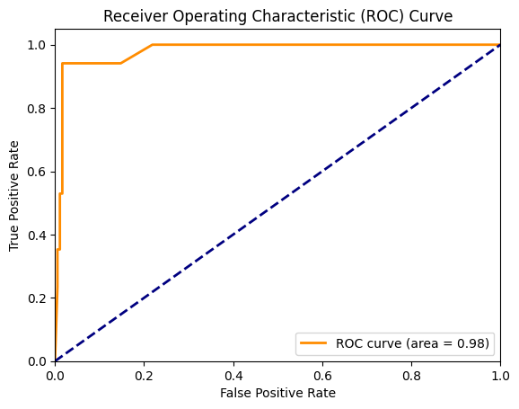

```python
import matplotlib.pyplot as plt
from sklearn.metrics import roc_curve, roc_auc_score

# Predict the probabilities of the positive class
y_prob = model.predict_proba(X_test)[:, 1]

# Calculate ROC curve
fpr, tpr, thresholds = roc_curve(y_test, y_prob)

# Calculate ROC AUC score
roc_auc = roc_auc_score(y_test, y_prob)

# Plot the ROC curve
plt.figure()
plt.plot(fpr, tpr, color='darkorange', lw=2, label='ROC curve (area = %0.2f)' % roc_auc)
plt.plot([0, 1], [0, 1], color='navy', lw=2, linestyle='--')
plt.xlim([0.0, 1.0])
plt.ylim([0.0, 1.05])
plt.xlabel('False Positive Rate')
plt.ylabel('True Positive Rate')
plt.title('Receiver Operating Characteristic (ROC) Curve')
plt.legend(loc="lower right")
plt.show()
```